# Прогнозирование заказов такси

Компания «Чётенькое такси» собрала исторические данные о заказах такси в аэропортах. Чтобы привлекать больше водителей в период пиковой нагрузки, нужно спрогнозировать количество заказов такси на следующий час. Постройте модель для такого предсказания.

Значение метрики *RMSE* на тестовой выборке должно быть не больше 48.

Вам нужно:

1. Загрузить данные и выполнить их ресемплирование по одному часу.
2. Проанализировать данные.
3. Обучить разные модели с различными гиперпараметрами. Сделать тестовую выборку размером 10% от исходных данных.
4. Проверить данные на тестовой выборке и сделать выводы.

Данные лежат в файле `taxi.csv`. Количество заказов находится в столбце `num_orders` (от англ. *number of orders*, «число заказов»).

**План:**

1. Подготовка
   - Загрузка
   - Переработка
2. Анализ
   - Выбросы
   - Ресемплирование: 1 Час
   - Скользящее среднее
   - Сезонность и тренды
   - День недели
   - Стационарность
   - Разности ряда
3. Обучение
   - Признаки
     - Предыдущие дни
   - Контрольная выборка
   - Подготовка валидации
   - SearchCV
     - Dummy
     - LGBMRegressor
     - LinearRegression
     - RandomForestRegressor
4. Контроль
   - RMSE
   - R2
   - MAE
   - Dummy
5. Заключение

**Содержание**

1. Подготовка
2. Анализ  
   2.1. Аномалии  
   2.2. Ресемплирование  
   2.3. Сезонность и тренды  
   2.4. Разности временного ряда
3. Обучение  
   3.1. Признаки  
   3.2. ЦП, Контрольная выборка  
   3.3. Подготовка валидации.  
   3.4. Dummy  
   3.5. LGBM  
   3.6. LinearRegression  
   3.7. RandomForest
4. Тестирование  
   4.1. LinReg лучший  
   4.2. Вменяемость - DummyPrevious
5. Заключение

Служебные Функции

```python
import pandas as pd
import matplotlib.pyplot as plt
import seaborn as sns
import calendar
import os

from statsmodels.tsa.seasonal import seasonal_decompose
from sklearn.model_selection import (train_test_split, TimeSeriesSplit, cross_val_score,
                                     GridSearchCV, RandomizedSearchCV)

from sklearn.dummy import DummyRegressor
from sklearn.linear_model import LinearRegression
from sklearn.ensemble import RandomForestRegressor
from lightgbm import LGBMRegressor

from sklearn.metrics import mean_absolute_error, r2_score, mean_squared_error

from sklearn.base import BaseEstimator, RegressorMixin
```

```python
plt.rcParams["figure.figsize"] = (8,8)
plt.rc('axes', titlesize='x-large')
RANDOM = 0
pd.set_option('max_rows', 60)
```

## 1. Подготовка

```python
path_local = 'datasets/'
path_platform = '/datasets/'
path_extra = ''

df_list = [
    'taxi.csv',
]

if os.path.exists(path_local) and all(list(map(os.path.exists, map(lambda x: path_local + x, df_list)))):
    df_dir = path_local
    print("Файлы найдены.")
elif os.path.exists(path_platform) and all(list(map(os.path.exists, map(lambda x: path_platform + x, df_list)))):
    df_dir = path_platform
    print("Файлы найдены.")
elif os.path.exists(path_extra) and all(list(map(os.path.exists, map(lambda x: path_extra + x, df_list)))):
    df_dir = path_extra
    print("Файлы найдены.")
elif all(list(map(os.path.exists, df_list))):
    df_dir = ''
    print("Файлы найдены.")
else:
    print("Директория не найдена. Файлы не найдены в текущей.")

df = pd.read_csv(os.path.join(df_dir, 'taxi.csv'), parse_dates=['datetime'])
```

```
Файлы найдены.
```

```python
path_local = 'datasets/taxi.csv'
path_platform = '/datasets/taxi.csv'

if os.path.exists(path_local):
    df = pd.read_csv(path_local, parse_dates=['datetime'])
elif os.path.exists(path_platform):
    df = pd.read_csv(path_platform, parse_dates=['datetime'])
else:
    print("Файл не найден")
```

```python
df.info()
```

```
<class 'pandas.core.frame.DataFrame'>
RangeIndex: 26496 entries, 0 to 26495
Data columns (total 2 columns):
 #   Column      Non-Null Count  Dtype
---  ------      --------------  -----
 0   datetime    26496 non-null  datetime64[ns]
 1   num_orders  26496 non-null  int64
dtypes: datetime64[ns](1), int64(1)
memory usage: 414.1 KB
```

```python
df.duplicated().sum()
```

```
0
```

```python
df.isna().sum()
```

```
datetime      0
num_orders    0
dtype: int64
```

```python
df.describe(datetime_is_numeric=True)
```

|  | datetime | num_orders |
| --- | --- | --- |
| count | 26496 | 26496.000000 |
| mean | 2018-05-31 23:55:00 | 14.070463 |
| min | 2018-03-01 00:00:00 | 0.000000 |
| 25% | 2018-04-15 23:57:30 | 8.000000 |
| 50% | 2018-05-31 23:55:00 | 13.000000 |
| 75% | 2018-07-16 23:52:30 | 19.000000 |
| max | 2018-08-31 23:50:00 | 119.000000 |
| std | NaN | 9.211330 |

```python
df = df.set_index('datetime')
```

**Выводы**

Данные содержат только две колонки, время и количество заказов, для того чтобы правильно провести подготовку, сначала проверили дубликаты, потом задали столбец дат как индекс. Пропусков нет, дубликатов нет, типы данных уместны. Всего 26496 записей.

## 2. Анализ

### 2.1. Аномалии

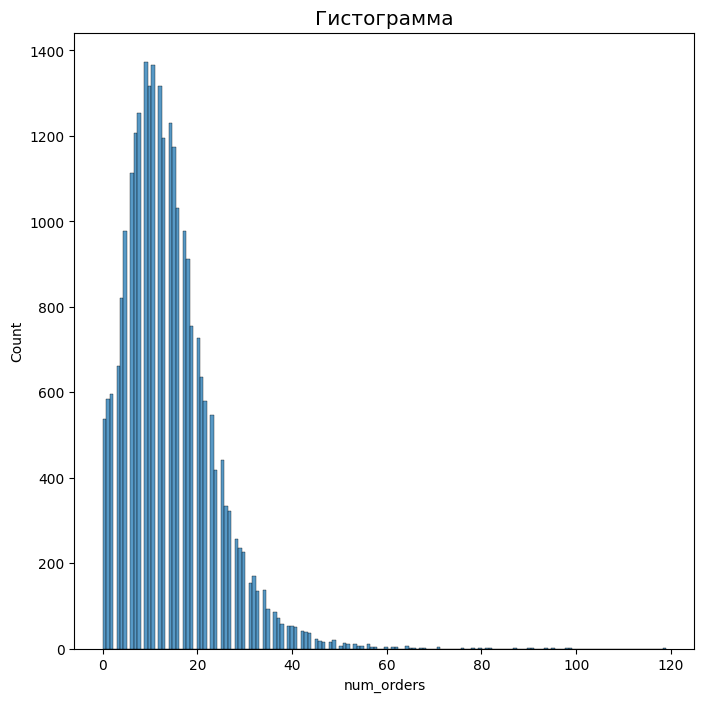

```python
sns.histplot(x=df.num_orders);
plt.title('Гистограмма');
```

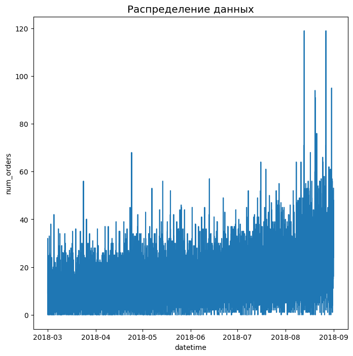

```python
sns.lineplot(y=df.num_orders, x=df.index);
plt.title('Распределение данных');
```

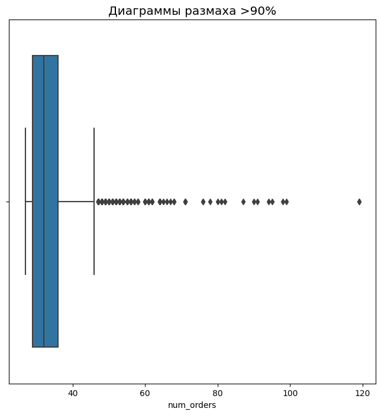

```python
sns.boxplot(x=df.num_orders[df.num_orders > df.num_orders.quantile(.9)], orient='h');
plt.title("Диаграммы размаха >90%");
```

**Выводы**

В целом выбросы правдоподобны, сравнивая с 10% наибольших значений, их достаточно много, и самый большой не слишком сильно превосходит предыдущие.

### 2.2. Ресемплирование

```python
dfh = df.resample('1H').sum() # DF by hour
dfh
```

| datetime | num_orders |
| --- | --- |
| 2018-03-01 00:00:00 | 124 |
| 2018-03-01 01:00:00 | 85 |
| 2018-03-01 02:00:00 | 71 |
| 2018-03-01 03:00:00 | 66 |
| 2018-03-01 04:00:00 | 43 |
| ... | ... |
| 2018-08-31 19:00:00 | 136 |
| 2018-08-31 20:00:00 | 154 |
| 2018-08-31 21:00:00 | 159 |
| 2018-08-31 22:00:00 | 223 |
| 2018-08-31 23:00:00 | 205 |

4416 rows × 1 columns

```python
dfh.describe()
```

|  | num_orders |
| --- | --- |
| count | 4416.000000 |
| mean | 84.422781 |
| std | 45.023853 |
| min | 0.000000 |
| 25% | 54.000000 |
| 50% | 78.000000 |
| 75% | 107.000000 |
| max | 462.000000 |

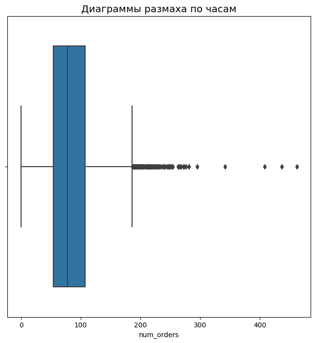

```python
sns.boxplot(x=dfh.num_orders, orient='h');
plt.title("Диаграммы размаха по часам");
```

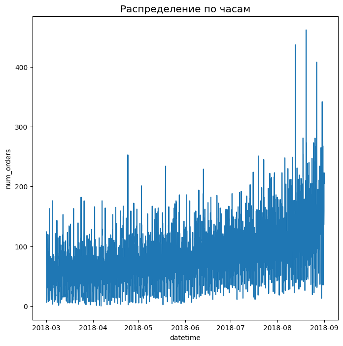

```python
sns.lineplot(y=dfh.num_orders, x=dfh.index);
plt.title("Распределение по часам");
```

```python
dfh.num_orders.quantile(.98)
```

```
196.69999999999982
```

```python
dfh[dfh.num_orders > dfh.num_orders.quantile(.98)].index.hour.value_counts()
```

```
0     25
2     14
1     10
16     7
4      6
23     6
3      5
17     4
10     3
22     3
9      2
21     2
15     1
18     1
Name: datetime, dtype: int64
```

**Выводы**

После ресемплирования можно увидеть, что выбросы по часам приходятся в основном на время около полуночи, довольно странное распределение, но можно предположить, что люди спешат вернутся домой.

### 2.3. Сезонность и тренды

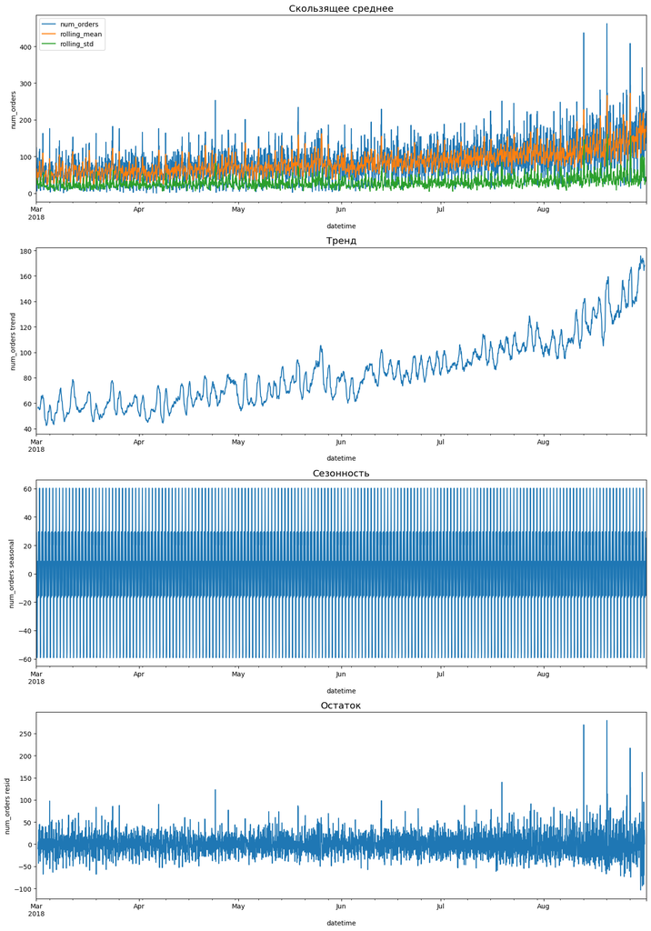

```python
decomposed = seasonal_decompose(dfh.num_orders)
plt.figure(figsize=(14, 20))
dfh['rolling_mean'] = dfh.num_orders.rolling(6, center=True, closed='left').mean()
dfh['rolling_std'] = dfh.num_orders.rolling(6, center=True, closed='left').std()

plt.subplot(411)
dfh.plot(ax=plt.gca())
plt.title('Скользящее среднее')
dfh.drop(['rolling_mean', 'rolling_std'], axis=1, inplace=True)
plt.ylabel('num_orders')

plt.subplot(412)
decomposed.trend.plot(ax=plt.gca())
plt.title('Тренд')
plt.ylabel('num_orders trend')

plt.subplot(413)
decomposed.seasonal.plot(ax=plt.gca())
plt.title('Сезонность')
plt.ylabel('num_orders seasonal')

plt.subplot(414)
decomposed.resid.plot(ax=plt.gca())
plt.title('Остаток')
plt.ylabel('num_orders resid')
plt.tight_layout();
```

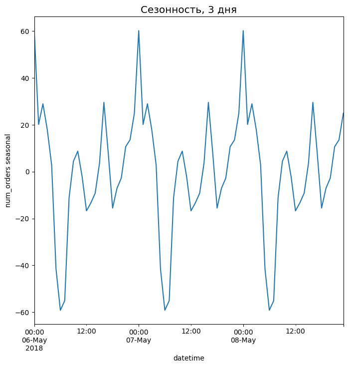

```python
three_days_may_seasonal = decomposed.seasonal['2018-05-06':'2018-05-08']

three_days_may_seasonal.plot();
plt.ylabel('num_orders seasonal')
plt.title('Сезонность, 3 дня');
```

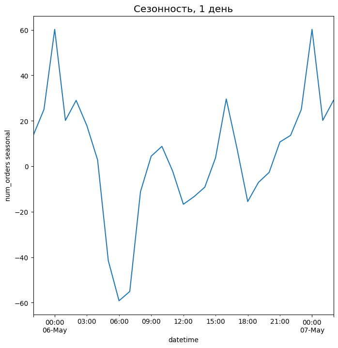

```python
one_day_may_seasonal = decomposed.seasonal['2018-05-05-22':'2018-05-07-02']

one_day_may_seasonal.plot();
plt.ylabel('num_orders seasonal')
plt.title('Сезонность, 1 день');
```

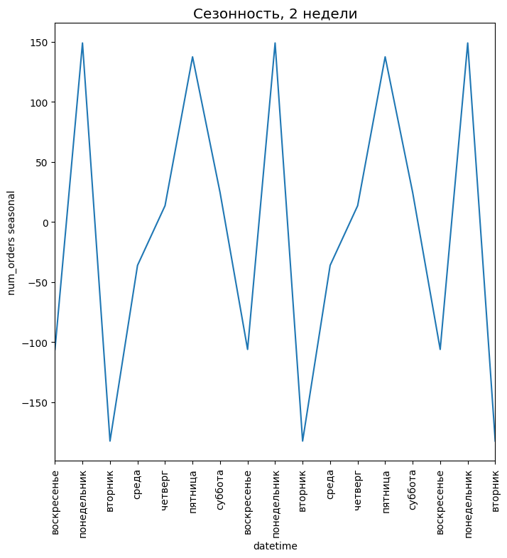

```python
two_weeks_may_seasonal = seasonal_decompose(dfh.resample('1D').sum().num_orders).seasonal['2018-05-06':'2018-05-22']
with calendar.different_locale('ru'):
    week_dict_ru = dict(enumerate(calendar.day_name))

two_weeks_may_seasonal.plot();
plt.xticks(two_weeks_may_seasonal.index, pd.Series(two_weeks_may_seasonal.index.weekday).replace(week_dict_ru), rotation=90)
plt.ylabel('num_orders seasonal')
plt.title('Сезонность, 2 недели');
```

**Выводы**

В целом значения скользящего среднего отклонения довольно сильно колеблется. Наблюдается тренд на повышение. Ряд не стационарен. Имеется выраженная суточная сезонность пиковые значение около полуночи, минимальное ранним утром, значительные скачки ближе к полдню и к четырём часам. Учитывая что в данных представлена информация по заказам такси в аэропортах, можно предположить, что сезонность объясняется временем и частотой прибытия рейсов, если это так, то исследуемые аэропорты принимают рейсы в эти интервалы. Нет явных закономерностей описывающих остаток. Также имеется сезонность по дням недели, что тоже может говорить о малом количестве рейсов во вторник и воскресенье, и большом в понедельник и пятницу.